# satRday - Round Turn Trade Simulation in txnsim()

updated 15 March 2018

## R/Finance 2018

[https://github.com/jaymon0703/satRday-2018—Round-Turn-Trade-Simulation](https://github.com/jaymon0703/satRday-2018---Round-Turn-Trade-Simulation)

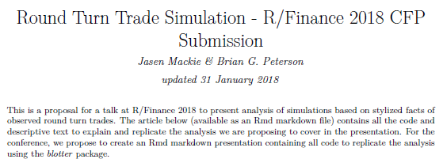

## You have a backtest, now what?

[figure not shown]

## Why be skeptical?

"A good analyst should be very skeptical of their own results, lest they lose money deploying a bad strategy" - Brian Peterson

## Simulate portfolio PL

- Simulate the strategy to get a sense of the distribution of possible outcomes
- for example, maximum drawdowns

## mcsim()

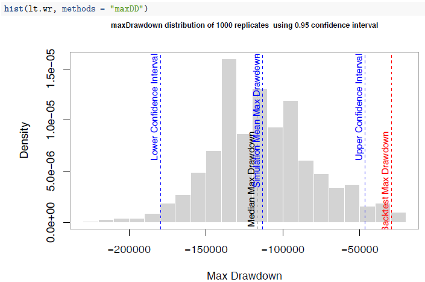

## Simulate round turn trades

- For greater transparency, simulate round turn trades (see **blotter::txnsim()**)
- https://github.com/braverock/blotter/blob/master/R/txnsim.R

## blotter::txnsim

- Stylized facts
  - percent time in market versus out
  - ratio of duration long:short periods
  - number of levels or layered trades observed, limited by max position
- Round turn trade definition
  - *flat.to.flat*
  - *flat.to.reduced*
  - *increased.to.reduced*

## Longtrend demo

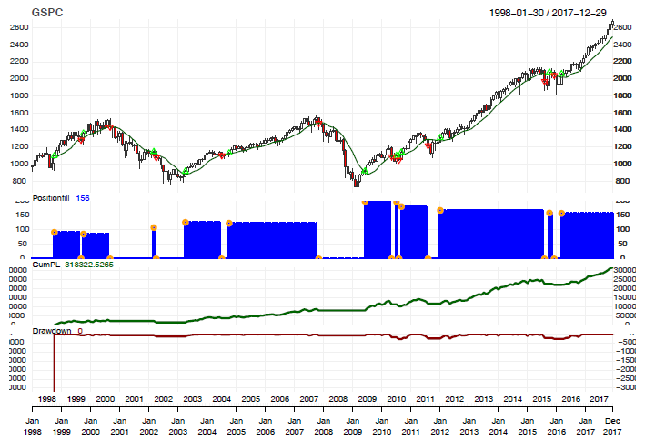

## Bbands demo

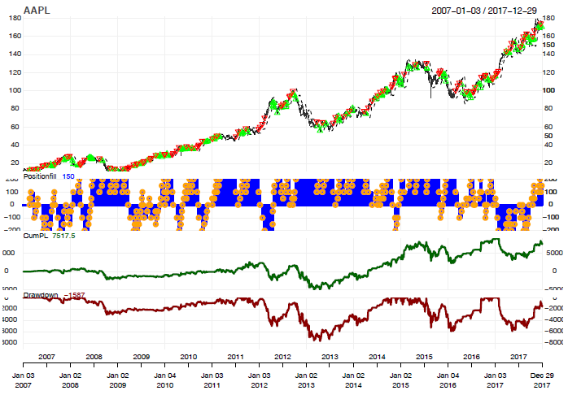

## plot "longtrend" round turn trades using txnsim

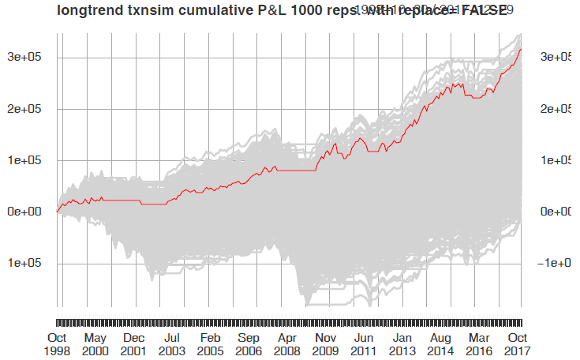

## plot "longtrend" portfolio PL using mcsim

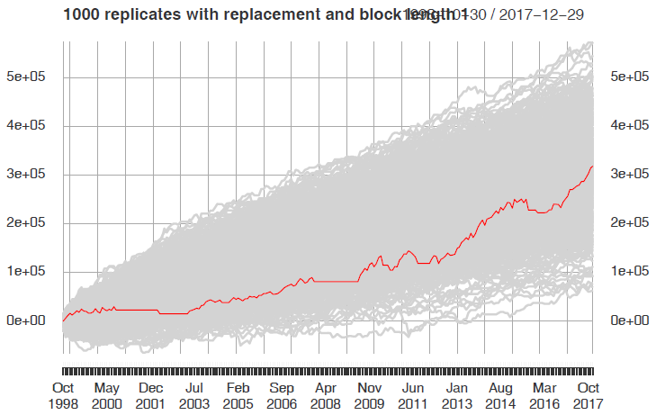

## plot "bbands" using txnsim

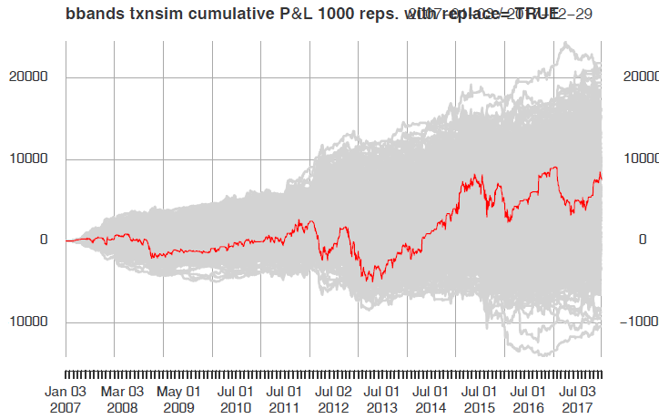

## Future Work

- Additional simulation methodologies
  - CSCV per Bailey and Lopez de Prado
  - simulated or resampled market data
  - applying stylized facts to other market data
- Additional models for analysing likelihood of overfitting
- Adding configurability for type of stylized fact to include in the analysis
- Optimisation

## Conclusion

We believe txnsim() is a significant contribution for any analyst seeking to evaluate the question of "skill vs. luck" of the observed trades, or for more broadly understanding what is theoretically possible with a certain trading cadence and style.

## Resources and References

- Brian G. Peterson, *"Developing & Backtesting Systematic Trading Strategies"* - http://goo.gl/na4u5d
- Harvey, Campbell R., and Yan Liu. 2015. *"Backtesting."* SSRN. https://papers.ssrn.com/sol3/papers.cfm?abstract_id=2345489
- Burns, Patrick 2006. *"Random Portfolios for Evaluating Trading Strategies."* http://www.burns-stat.com/pages/Working/evalstrat.pdf
- Bailey, David H, Jonathan M Borwein, Marcos Lòpez de Prado, and Qiji Jim Zhu. 2014. *"The Probability of Backtest Overfitting."* https://papers.ssrn.com/sol3/papers.cfm?abstract_id=2326253.
- Mackie, Jasen, Brian G. Peterson. 2018. *"Round Turn Trade Simulation - R/Finance 2018 CFP Submission."* [https://github.com/jaymon0703/satRday-2018—Round-Turn-Trade-Simulation/blob/master/Round_Turn_Trade_Simulation_FINAL.pdf](https://github.com/jaymon0703/satRday-2018---Round-Turn-Trade-Simulation/blob/master/Round_Turn_Trade_Simulation_FINAL.pdf)
- Tomasini, Emilio, and Urban Jaekle. 2009. *"Trading Systems: A New Approach to System Development and Portfolio Optimisation."*

## Thanks

- Thank you for listening
- Thank you to my family
- Special thanks to:
  - Brian Peterson
  - Joshua Ulrich
  - Peter Carl
  - Jeff Ryan
  - Dirk Eddelbuettel
  - Ross Bennett
  - and many more package authors and community members